# Text Mining - Harry Potter and the Prisoner of Azkaban

2025-04-05

## Libraries

```r
library(tidyverse)
library(stringr)
library(dplyr)
library(readr)
library(tm)
library(textstem)
library(udpipe)
library(stopwords)
library(tidytext)
library(ggplot2)
library(syuzhet)
library(treemapify)
library(scales)
library(widyr)
library(igraph)
library(ggraph)
```

As a result of the draw we made as a group, I will represent the Hufflepuff House from the Harry Potter Universe. For future use, let’s set our colour palette.

```r
hufflepuff_palette <- c(
  "#FFC107",
  "#D2691E",
  "#C19A6B",
  "#F5DEB3",
  "#FFA500",
  "#FFD54F",
  "#A0522D",
  "#5C2E0D",
  "#DEB887",
  "#FFECB3"
)
```

## Reading the book and script

```r
azkaban_book <- read_file("data/azkaban_book.txt")

azkaban_script <- read_file("data/azkaban_script.txt")

# making the book a tibble
azkaban_book <- tibble(text = azkaban_book)

# split the script into lines and store as a tibble
azkaban_script <- tibble(text = str_split(azkaban_script, pattern = "\n") |> unlist())
```

For a comprehensive stopword removing:

```r
ud_model <- udpipe_download_model(language = "english")
ud_model <- udpipe_load_model(ud_model$file_model)
```

## Word Frequencies for Book and Script

Tokenizing splits text into individual words or units, like turning “Harry runs fast” into “Harry”, “runs”, “fast”.

Lemmatizing reduces words to their base form, so “runs” and “running” both become “run”.

Removing stopwords filters out common words that don’t carry much meaning, like taking “the” and “is” out of “the spell is unmerciful” to leave “spell” and “unmerciful”.

### The book

‘udpipe_annotate’ does tokenization + POS tagging + lemmatization.

Part-of-speech (POS) tags: Identifying whether a word is a noun, verb, adjective, etc.

Lemmatization: Converting words to their base form (e.g., “running” → “run”).

```r
# annotating text with POS tags and converting to dataframe
tokens_azkaban_book <- udpipe_annotate(ud_model, x = azkaban_book$text) |>
  as.data.frame()

# loading built-in stopwords list
stop_words_azkaban <- stopwords(source = "smart")

# clean tokens by filtering out verbs, punctuation, pronouns, stopwords, and empty lemmas
clean_tokens_azkaban_book <- tokens_azkaban_book |>
  filter(upos != "VERB",
         upos != "PUNCT",
         upos != "PRON",
         !grepl("[[:punct:]]", lemma),
         !lemma %in% stop_words_azkaban,
         lemma != "") |>
  pull(lemma)
```

#### Term Frequencies

An interesting finding at first glance is that in the book Hagrid is mentioned more than Professor Snape and Sirius Black (However it is worth noting that Sirius Black is referred to as ‘Black’ and ‘Sirius’, which might mean that his name is mentioned more than both Hagrid and Snape). This is interesting to those who are familiar with the movie. Professor Lupin, the lycanthrope, is central to the story.

In the script, Hagrid is given less mentions compared to Snape and Sirius Black.

```r
# to see clearly the most frequent words
clean_tokens_azkaban_book |>
  table() |>
  sort(decreasing = TRUE) |>
  head(50)
```

```
## clean_tokens_azkaban_book
##      Harry        Ron   Hermione      Lupin  Professor       back     Hagrid
##       2048        787        489        408        388        354        267
##      Snape      Black       time        eye       hand     Malfoy      black
##        245        205        201        197        191        189        181
##       face       door Dumbledore       head      voice     Sirius   dementor
##        180        163        163        159        157        137        135
##       year Gryffindor       room      thing    Weasley       good McGonagall
##        126        123        120        118        118        115        113
##     Potter       wand      Fudge    Neville Crookshank       long     moment
##        110        110        107        106        103        102        102
##  Pettigrew      table       foot      class      front   Buckbeak       aunt
##        102         98         96         95         95         93         89
##   Hogwarts     inside  Trelawney     castle      uncle   Firebolt      large
##         88         88         88         86         85         84         83
##      Madam
##         83
```

#### Term Frequencies - but as percentages

One thing we’d like to know is whether some characters are mentioned less in the script compared to the book.

The book puts Harry, Ron, Hermione, Lupin, Hagrid, and Sirius Black in the centre of the story in Azkaban. Professor Snape is also mentioned with a fair frequency, close to that of Hagrid.

```r
# get word frequency table
book_word_freq <- table(clean_tokens_azkaban_book)

# convert to percentage
word_freq_percent <- prop.table(book_word_freq) * 100

# show top 50 most frequent words with percentages
sort(word_freq_percent, decreasing = TRUE) |> head(50)
```

```
## clean_tokens_azkaban_book
##      Harry        Ron   Hermione      Lupin  Professor       back     Hagrid
##  6.1848821  2.3767101  1.4767614  1.2321445  1.1717452  1.0690665  0.8063298
##      Snape      Black       time        eye       hand     Malfoy      black
##  0.7398907  0.6190922  0.6070124  0.5949325  0.5768127  0.5707728  0.5466131
##       face       door Dumbledore       head      voice     Sirius   dementor
##  0.5435932  0.4922538  0.4922538  0.4801739  0.4741340  0.4137348  0.4076949
##       year Gryffindor       room      thing    Weasley       good McGonagall
##  0.3805152  0.3714553  0.3623954  0.3563555  0.3563555  0.3472956  0.3412557
##     Potter       wand      Fudge    Neville Crookshank       long     moment
##  0.3321958  0.3321958  0.3231359  0.3201160  0.3110561  0.3080361  0.3080361
##  Pettigrew      table       foot      class      front   Buckbeak       aunt
##  0.3080361  0.2959563  0.2899163  0.2868964  0.2868964  0.2808565  0.2687766
##   Hogwarts     inside  Trelawney     castle      uncle   Firebolt      large
##  0.2657567  0.2657567  0.2657567  0.2597167  0.2566968  0.2536768  0.2506568
##      Madam
##  0.2506568
```

### The script

```r
# annotate the script text with udpipe and convert to dataframe
tokens_azkaban_script <- udpipe_annotate(ud_model, x = azkaban_script$text) |>
  as.data.frame()


# getting the stopwords
stop_words_script <- stopwords(source = "smart")


# clean tokens by filtering out verbs, punctuation, pronouns, stopwords, and empty lemmas
clean_tokens_azkaban_script <- tokens_azkaban_script |>
  filter(upos != "VERB",
         upos != "PUNCT",
         upos != "PRON",
         !grepl("[[:punct:]]", lemma),
         !lemma %in% stop_words_script,
         lemma != "") |>
  pull(lemma)
```

#### Term frequencies - the script

```r
# get word frequencies for the cleaned script tokens
script_word_freq <- table(clean_tokens_azkaban_script)

# to percentage
script_word_freq_percent <- prop.table(script_word_freq) * 100

# show top 50 most frequent words with percentages
sort(script_word_freq_percent, decreasing = TRUE) |> head(50)
```

```
## clean_tokens_azkaban_script
##      Harry   Hermione        Ron  Professor  continued      black      LUPIN
##  6.6915158  2.1654242  1.8903088  1.3312034  1.3223287  0.9939652  0.8519702
##        eye      Lupin      night     Sirius       back      Snape       hand
##  0.7720980  0.7454739  0.6922258  0.6922258  0.6744764  0.6212283  0.5946042
##   continue        INT   Buckbeak Dumbledore       time     Hagrid       door
##  0.5857295  0.5236067  0.4881079  0.4881079  0.4792332  0.4703585  0.4614838
##        ext   Dementor       wand     glance        day       head     window
##  0.4526092  0.4437345  0.4171104  0.3993610  0.3904863  0.3638623  0.3638623
##       turn       tree    Neville     HAGRId       room          2       aunt
##  0.3372382  0.3283635  0.3106141  0.3017394  0.3017394  0.2839901  0.2839901
##       good  Pettigrew       face      Marge      Tower       Fred     Malfoy
##  0.2839901  0.2751154  0.2573660  0.2573660  0.2484913  0.2396166  0.2396166
##        map   werewolf        dog       open     Potter       rise     castle
##  0.2396166  0.2396166  0.2307419  0.2307419  0.2307419  0.2307419  0.2129925
##    forward
##  0.2129925
```

### Comparison - book vs script

To summarise:

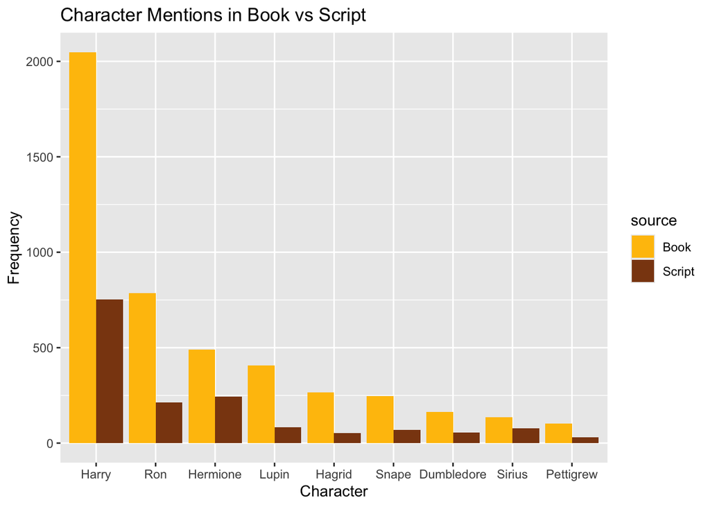

```r
# to compare main characters
characters <- c("Harry", "Hermione", "Ron", "Sirius", "Snape", "Hagrid", "Dumbledore", "Lupin", "Pettigrew")

#  mentions of each character in both the book and script
book_characters <- clean_tokens_azkaban_book[clean_tokens_azkaban_book %in% characters]
script_characters <- clean_tokens_azkaban_script[clean_tokens_azkaban_script %in% characters]

# frequency tables
book_character_freq <- table(book_characters)
script_character_freq <- table(script_characters)

# a comparison data frame
character_comparison_df <- data.frame(
  character = rep(characters, times = 2),
  source = rep(c("Book", "Script"), each = length(characters)),
  frequency = c(
    as.integer(book_character_freq[characters]),
    as.integer(script_character_freq[characters])
  )
)

# total frequency per character
total_freq <- aggregate(frequency ~ character, data = character_comparison_df, sum)

# reordering character factor based on total frequency
character_comparison_df$character <- factor(
  character_comparison_df$character,
  levels = total_freq$character[order(-total_freq$frequency)]
)

# plot
ggplot(character_comparison_df, aes(x = character, y = frequency, fill = source)) +
  geom_bar(stat = "identity", position = "dodge") +
  labs(title = "Character Mentions in Book vs Script", x = "Character", y = "Frequency") +
  scale_fill_manual(values = c("Book" = "#FFC107", "Script" = "#8B4513"))
```

## Sentiment Analysis - book vs script

In this section, we will conduct a sentiment analysis on the book and script in general, as well as a sentiment analysis of the characters from both texts.

For a quick overview of the sentiments in the book and script, ordered:

**The book:**

Negative - positive - fear - anger - sadness - trust - disgust - joy - surprise

### The book

The book carries mostly negative sentiments. To go into detail, the atmosphere in the book is marked by fear, anger, and sadness sentiments. Trust, joy, and surprise fall behind those negative sentiments, giving us hints about the overall climate.

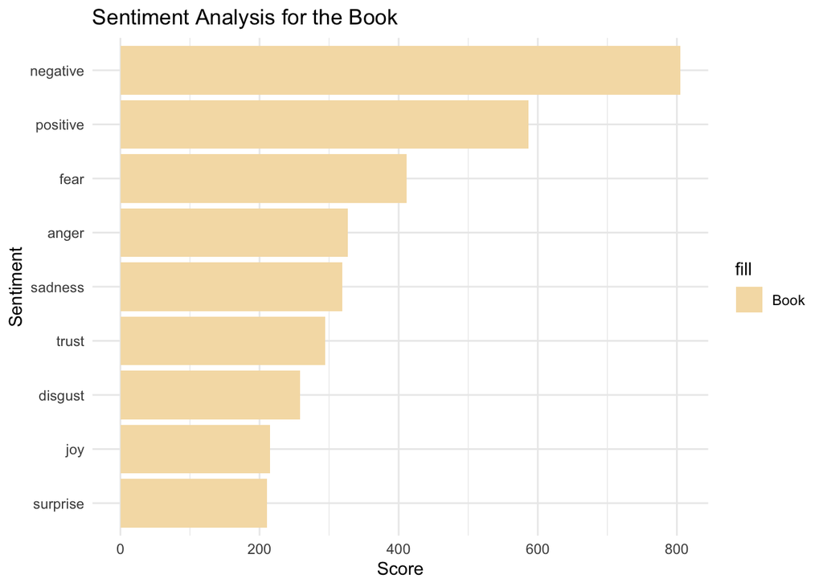

```r
# get sentiment scores for the book
book_sentiment <- get_nrc_sentiment(azkaban_book$text)

# calculate overall sentiment for the book (sum of positive and negative scores)
book_sentiment_score <- book_sentiment %>%
  summarise(across(everything(), sum)) %>%
  unlist()  # Convert the summary to a vector

# create a data frame for the sentiment comparison
sentiment_categories <- c("positive", "negative", "anger", "disgust", "fear", "joy", "sadness", "surprise", "trust")

# ensuring the sentiment score vector has the correct length
book_sentiment_score <- book_sentiment_score[sentiment_categories]

sentiment_comparison_df <- data.frame(
  sentiment = sentiment_categories,
  book_score = book_sentiment_score
)

# the sentiment data in descending order
sentiment_comparison_df <- sentiment_comparison_df %>%
  arrange(desc(book_score))

# plot sentiment analysis for the book
ggplot(sentiment_comparison_df, aes(x = reorder(sentiment, book_score), y = book_score, fill = "Book")) +
  geom_bar(stat = "identity", position = "dodge") +
  labs(title = "Sentiment Analysis for the Book", x = "Sentiment", y = "Score") +
  scale_fill_manual(values = c("Book" = "#F5DEB3")) +
  theme_minimal() +
  coord_flip()
```

### Sentiment analysis for characters - book

Picking the characters we want to see. This list will be used later for the script as well.

```r
azkaban_characters <- c("Harry", "Ron", "Hermione", "Hagrid", "Dumbledore",
                        "Snape", "McGonagall", "Malfoy", "Neville", "Lupin",
                        "Pettigrew", "Black")
```

```r
context_sentiment_df <- tokens_azkaban_book %>%
  mutate(
    is_character = token %in% azkaban_characters,
    token_id = as.integer(token_id)
  ) %>%
  group_by(doc_id) %>%
  mutate(character_token_id = ifelse(is_character, token_id, NA_integer_)) %>%
  fill(character_token_id, .direction = "downup") %>%
  filter(!is.na(character_token_id)) %>%
  mutate(character_token_id = as.integer(character_token_id)) %>%
  filter(abs(token_id - character_token_id) <= 5, !is_character) %>%
  mutate(word = token) %>%
  inner_join(get_sentiments("nrc"), by = "word") %>%
  group_by(doc_id, character_token_id, sentiment) %>%
  summarise(sentiment_count = n(), .groups = "drop")
head(context_sentiment_df, 20)
```

```
## # A tibble: 20 × 4
##    doc_id character_token_id sentiment    sentiment_count
##    <chr>               <int> <chr>                  <int>
##  1 doc1                    1 anger                    116
##  2 doc1                    1 anticipation             168
##  3 doc1                    1 disgust                  101
##  4 doc1                    1 fear                     174
##  5 doc1                    1 joy                       92
##  6 doc1                    1 negative                 342
##  7 doc1                    1 positive                 240
##  8 doc1                    1 sadness                  146
##  9 doc1                    1 surprise                 130
## 10 doc1                    1 trust                    131
## 11 doc1                    2 anger                     45
## 12 doc1                    2 anticipation              54
## 13 doc1                    2 disgust                   32
## 14 doc1                    2 fear                      55
## 15 doc1                    2 joy                       34
## 16 doc1                    2 negative                 105
## 17 doc1                    2 positive                  84
## 18 doc1                    2 sadness                   48
## 19 doc1                    2 surprise                  42
## 20 doc1                    2 trust                     57
```

Let’s map `character_token_id` back to character names and summarize the sentiment for each character.

```r
context_sentiment_df <- context_sentiment_df %>%
  mutate(character = case_when(
    character_token_id == 1 ~ "Harry",
    character_token_id == 2 ~ "Ron",
    character_token_id == 3 ~ "Hermione",
    character_token_id == 4 ~ "Hagrid",
    character_token_id == 5 ~ "Dumbledore",
    character_token_id == 6 ~ "Snape",
    character_token_id == 7 ~ "McGonagall",
    character_token_id == 8 ~ "Malfoy",
    character_token_id == 9 ~ "Neville",
    character_token_id == 10 ~ "Lupin",
    character_token_id == 11 ~ "Pettigrew",
    character_token_id == 12 ~ "Black",
    TRUE ~ "Unknown"
  ))

# summing the sentiment counts by character
character_sentiment_summary <- context_sentiment_df %>%
  group_by(character, sentiment) %>%
  summarise(sentiment_count = sum(sentiment_count), .groups = "drop")

head(character_sentiment_summary, 20)
```

```
## # A tibble: 20 × 3
##    character  sentiment    sentiment_count
##    <chr>      <chr>                  <int>
##  1 Black      anger                     20
##  2 Black      anticipation              25
##  3 Black      disgust                   14
##  4 Black      fear                      30
##  5 Black      joy                       21
##  6 Black      negative                  44
##  7 Black      positive                  45
##  8 Black      sadness                   24
##  9 Black      surprise                  24
## 10 Black      trust                     28
## 11 Dumbledore anger                     29
## 12 Dumbledore anticipation              37
## 13 Dumbledore disgust                   20
## 14 Dumbledore fear                      33
## 15 Dumbledore joy                       33
## 16 Dumbledore negative                  72
## 17 Dumbledore positive                  73
## 18 Dumbledore sadness                   33
## 19 Dumbledore surprise                  35
## 20 Dumbledore trust                     45
```

# Character level Sentiment Distribution

All in all, the book mostly demonstrates negative sentiments such as fear, anger, disgust, and sadness.

[figure not shown]

```r
# we were getting an 'Unknown' sentiment. let's exclude that
filtered_sentiment_df <- character_sentiment_summary %>%
  filter(character != "Unknown")

# the treemap with the custom Hufflepuff palette
ggplot(filtered_sentiment_df, aes(area = sentiment_count, fill = sentiment, label = sentiment)) +
  geom_treemap() +
  geom_treemap_text(colour = "black", place = "centre", grow = TRUE, reflow = TRUE) +
  facet_wrap(~character, scales = "free") +
  scale_fill_manual(values = hufflepuff_palette) +  # for the hufflepuff palette
  labs(title = "Character-Level Sentiment Distribution",
       subtitle = "Treemap visualization of emotional tones for each character",
       fill = "Sentiment") +
  theme_minimal(base_family = "serif") +
  theme(
    strip.text = element_text(face = "bold", size = 12),
    plot.title = element_text(face = "bold", size = 18),
    plot.subtitle = element_text(size = 14)
  )
```

### The script

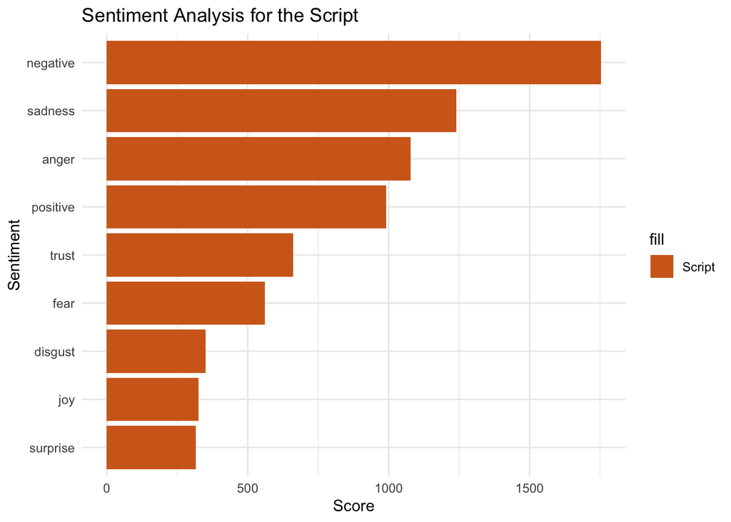

```r
# get sentiment scores for the script
script_sentiment <- get_nrc_sentiment(azkaban_script$text)

# calculate overall sentiment for the script (sum of positive and negative scores)
script_sentiment_score <- script_sentiment %>%
  summarise(across(everything(), sum)) %>%
  unlist()  # Convert the summary to a vector

# create a data frame for the sentiment comparison
script_sentiment_score <- script_sentiment_score[sentiment_categories]  # Align to categories

sentiment_comparison_df_script <- data.frame(
  sentiment = sentiment_categories,
  script_score = script_sentiment_score
)

# sentiment data in descending order
sentiment_comparison_df_script <- sentiment_comparison_df_script %>%
  arrange(desc(script_score))

# plot
ggplot(sentiment_comparison_df_script, aes(x = reorder(sentiment, script_score), y = script_score, fill = "Script")) +
  geom_bar(stat = "identity", position = "dodge") +
  labs(title = "Sentiment Analysis for the Script", x = "Sentiment", y = "Score") +
  scale_fill_manual(values = c("Script" = "#D2691E")) +
  theme_minimal() +
  coord_flip()
```

#### Character sentiments - the script

```r
context_sentiment_script <- tokens_azkaban_script %>%
  mutate(
    is_character = token %in% azkaban_characters,
    token_id = as.integer(token_id)
  ) %>%
  group_by(doc_id) %>%
  mutate(character_token_id = ifelse(is_character, token_id, NA_integer_)) %>%
  fill(character_token_id, .direction = "downup") %>%
  filter(!is.na(character_token_id)) %>%
  mutate(character_token_id = as.integer(character_token_id)) %>%
  filter(abs(token_id - character_token_id) <= 5, !is_character) %>%
  mutate(word = token) %>%
  inner_join(get_sentiments("nrc"), by = "word") %>%
  group_by(doc_id, character_token_id, sentiment) %>%
  summarise(sentiment_count = n(), .groups = "drop")
```

```r
# character mentions and their token ids
character_mentions_script <- tokens_azkaban_script %>%
  filter(token %in% azkaban_characters) %>%
  mutate(token_id = as.integer(token_id)) %>%
  select(doc_id, token_id, character = token)

# character names based on token_id
context_sentiment_script <- context_sentiment_script %>%
  left_join(character_mentions_script,
            by = c("doc_id", "character_token_id" = "token_id"))
# sentiment counts per character
character_sentiment_summary_script <- context_sentiment_script %>%
  group_by(character, sentiment) %>%
  summarise(sentiment_count = sum(sentiment_count), .groups = "drop")
```

Results highlight a strong presence of negative emotions, with “negative” being the most dominant, followed closely by sadness and anger.

Additionally, the movie script shows less focus on trust compared to the book, where Hagrid stands out as a beacon of trust and safety for Harry and others. Both the movie and book maintain a dark emotional landscape, but the movie shifts away from fear as the central emotion, opting for a wider negative tone

[figure not shown]

```r
# excluding unknown or NA characters if any
filtered_sentiment_script <- character_sentiment_summary_script %>%
  filter(!is.na(character))


# treemap plot for script
ggplot(filtered_sentiment_script, aes(area = sentiment_count, fill = sentiment, label = sentiment)) +
  geom_treemap() +
  geom_treemap_text(colour = "black", place = "centre", grow = TRUE, reflow = TRUE) +
  facet_wrap(~character, scales = "free") +
  scale_fill_manual(values = hufflepuff_palette) +
  labs(title = "Character-Level Sentiment Distribution (Script)",
       subtitle = "Treemap visualization of emotional tones around each character mention",
       fill = "Sentiment") +
  theme_minimal(base_family = "serif") +
  theme(
    strip.text = element_text(face = "bold", size = 12),
    plot.title = element_text(face = "bold", size = 18),
    plot.subtitle = element_text(size = 14)
  )
```

## Emotional arc of the book and the movie, how emotions change over the course of both documents

Below chunk divides the book and script into 100 equal segments based on token position and assigns a segment ID to each token. It then joins NRC sentiment labels to the tokens, and counts how many times each sentiment appears in each segment. This will help us understand the course of the book and script, and see which sentiments appear as the story progresses.

```r
n_segments <- 100

emotional_arc_book <- tokens_azkaban_book %>%
  mutate(segment = ntile(as.integer(token_id), n_segments)) %>%
  inner_join(get_sentiments("nrc"), by = c("token" = "word")) %>%
  count(segment, sentiment)

emotional_arc_script <- tokens_azkaban_script %>%
  mutate(segment = ntile(as.integer(token_id), n_segments)) %>%
  inner_join(get_sentiments("nrc"), by = c("token" = "word")) %>%
  count(segment, sentiment)

# emotional arcs for both texts

emotional_arc_book$source <- "Book"
emotional_arc_script$source <- "Script"

# combining
emotional_arc_combined <- bind_rows(emotional_arc_book, emotional_arc_script)
```

Below is the plot for the emotional arc progression comparison for the book and script across sentiments.

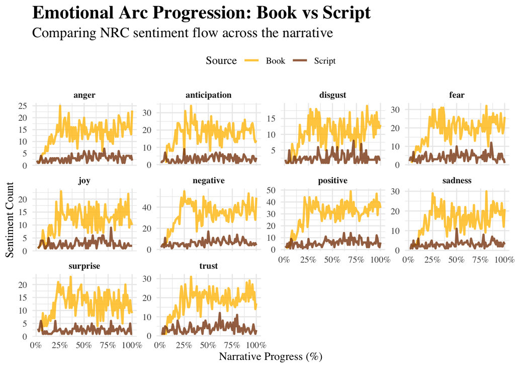

```r
ggplot(emotional_arc_combined, aes(x = segment, y = n, color = source)) +
  geom_line(size = 1, alpha = 0.8) +
  facet_wrap(~sentiment, scales = "free_y") +
  scale_color_manual(values = c("Book" = "#FFC107", "Script" = "#8B4513")) +
  scale_x_continuous(labels = percent_format(scale = 1)) +
  labs(
    title = "Emotional Arc Progression: Book vs Script",
    subtitle = "Comparing NRC sentiment flow across the narrative",
    x = "Narrative Progress (%)",
    y = "Sentiment Count",
    color = "Source"
  ) +
  theme_minimal(base_family = "serif") +
  theme(
    plot.title = element_text(size = 18, face = "bold"),
    plot.subtitle = element_text(size = 14),
    strip.text = element_text(face = "bold"),
    legend.position = "top"
  )
```

## Bigrams

We want to see the most frequent 20 bigrams from the book and script.

The bigram analysis for the “Harry Potter and the Prisoner of Azkaban” movie script highlights key themes and character focuses. “Professor Lupin” and “Sirius Black” stand out as the most frequent bigrams, indicating their central roles in the movie’s narrative, which aligns with their importance in the story as Harry’s allies and key figures in the plot surrounding Azkaban. Other character pairs like “Uncle Vernon,” “Cornelius Fudge,” “Aunt Marge,” “Professor Trelawney,” and “Professor McGonagall” reflect the script’s emphasis on authority figures and family dynamics, both at Hogwarts and in the Muggle world. Location-based bigrams like “Hogwarts Castle,” “Ext Hogwarts,” “Hagrid’s Hut,” and “Whomping Willow” underscore the significance of the Hogwarts setting and its magical elements in driving the story.

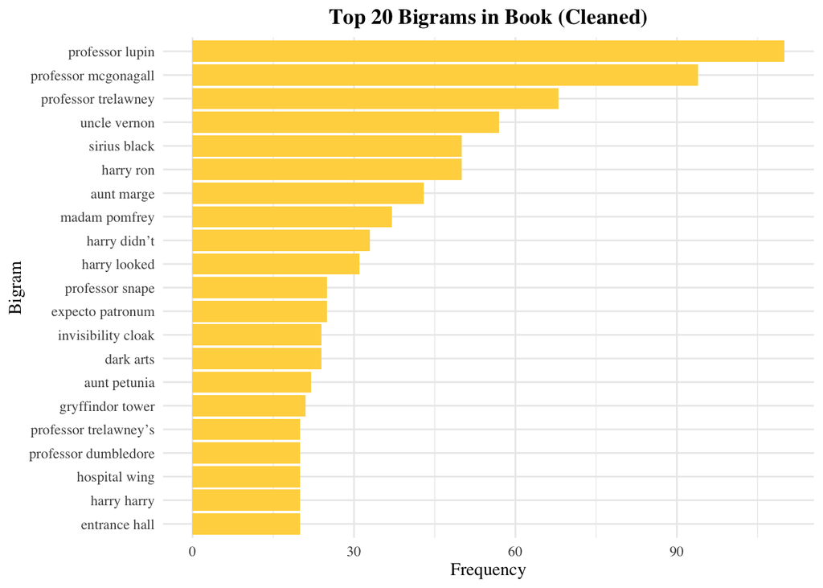

```r
# bigrams for book
azkaban_book_bigrams <- tibble(text = as.character(azkaban_book)) %>%
  unnest_tokens(bigram, text, token = "ngrams", n = 2)

# bigrams for script
azkaban_script_bigrams <- tibble(text = as.character(azkaban_script$text)) %>%
  unnest_tokens(bigram, text, token = "ngrams", n = 2)

# separate bigrams into two words
azkaban_book_bigrams_sep <- azkaban_book_bigrams %>%
  separate(bigram, into = c("word1", "word2"), sep = " ")

azkaban_script_bigrams_sep <- azkaban_script_bigrams %>%
  separate(bigram, into = c("word1", "word2"), sep = " ")

# removing stopwords
azkaban_book_bigrams_clean <- azkaban_book_bigrams_sep %>%
  filter(!word1 %in% stop_words$word,
         !word2 %in% stop_words$word,
         !is.na(word1), !is.na(word2)) %>%
  unite(bigram, word1, word2, sep = " ")

azkaban_script_bigrams_clean <- azkaban_script_bigrams_sep %>%
  filter(!word1 %in% stop_words$word,
         !word2 %in% stop_words$word,
         !is.na(word1), !is.na(word2)) %>%
  unite(bigram, word1, word2, sep = " ")


# top 20 bigrams for book
azkaban_book_bigrams_clean %>%
  count(bigram, sort = TRUE) %>%
  slice_max(order_by = n, n = 20) %>%
  ggplot(aes(x = reorder(bigram, n), y = n)) +
  geom_col(fill = "#FFD54F") +
  coord_flip() +
  labs(title = "Top 20 Bigrams in Book (Cleaned)",
       x = "Bigram", y = "Frequency") +
  theme_minimal(base_family = "serif") +
  theme(plot.title = element_text(hjust = 0.5, face = "bold"))
```

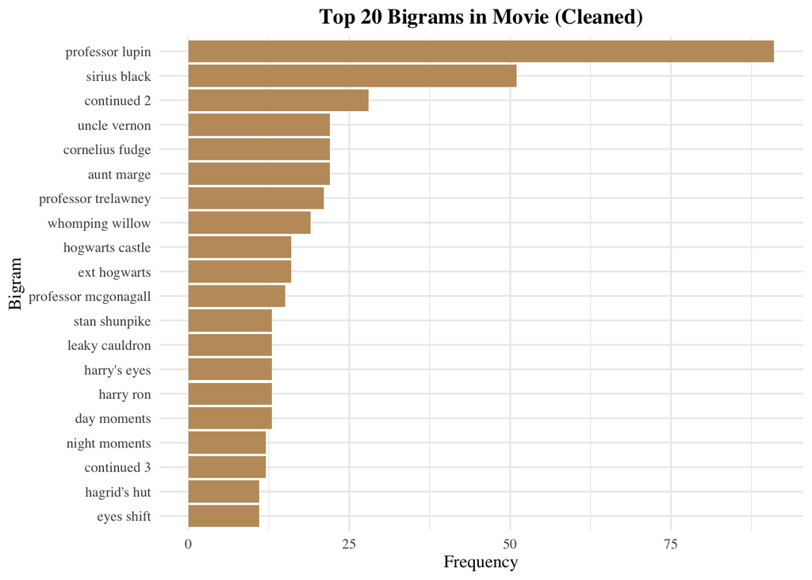

```r
# top 20 bigrams for script
azkaban_script_bigrams_clean %>%
  count(bigram, sort = TRUE) %>%
  slice_max(order_by = n, n = 20) %>%
  ggplot(aes(x = reorder(bigram, n), y = n)) +
  geom_col(fill = "#C19A6B") +
  coord_flip() +
  labs(title = "Top 20 Bigrams in Movie (Cleaned)",
       x = "Bigram", y = "Frequency") +
  theme_minimal(base_family = "serif") +
  theme(plot.title = element_text(hjust = 0.5, face = "bold"))
```

## Character co-occurrence network

The co-occurrence network for the book shows that Harry has the strongest connections with Ron and Hermione, indicating they are his closest companions in the story. Hermione and Ron also share a significant bond. Other notable relationships include Harry with Sirius Black, Hagrid, Lupin, Malfoy, and Snape, reflecting key interactions with these characters. Black and Ron, as well as Lupin and Ron, also have meaningful connections, suggesting their roles in the narrative intersect with Ron’s storyline.

To compare, we can say that Harry and Ron have the strongest bond, while the movie prioritizes Harry and Hermione. Hermione and Ron’s connection is more prominent in the film. The book includes Harry and Malfoy, but the movie omits this, instead highlighting new pairs like Lupin and Pettigrew, Harry and Pettigrew, Hagrid with Ron and Hermione, and Dumbledore with Harry. The film focuses more on the central trio, while the book spreads interactions across a wider cast.

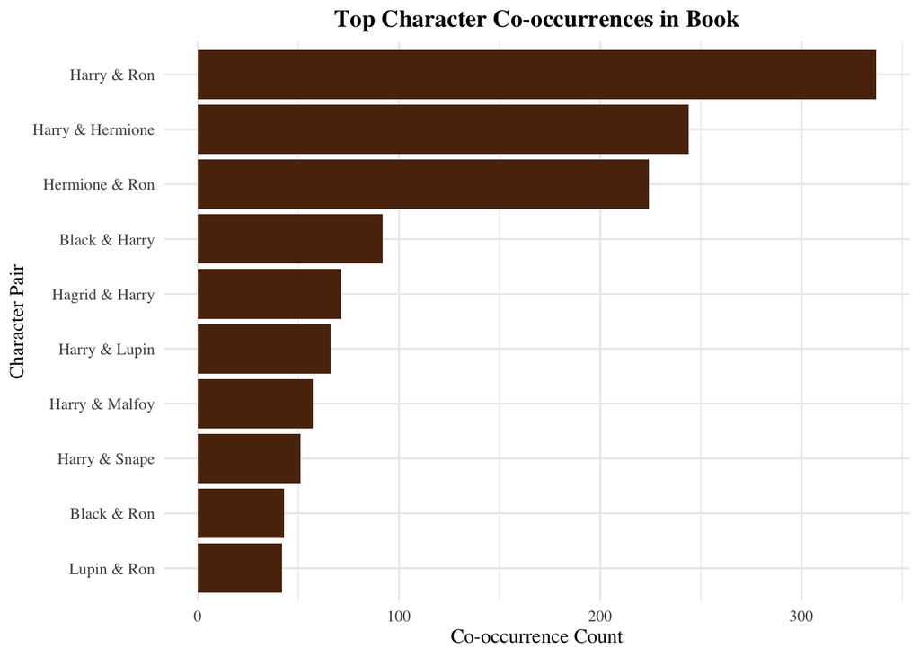

```r
# define characters of interest
character_list <- c("Harry", "Ron", "Hermione", "Hagrid", "Dumbledore",
                    "Snape", "McGonagall", "Malfoy", "Neville", "Lupin",
                    "Pettigrew", "Black")

# break book into smaller chunks (e.g., sentences)
azkaban_book_sentences <- unlist(str_split(azkaban_book, "(?<=[.!?])\\s+"))

# helper to extract character co-occurrence pairs
detect_character_pairs <- function(text_data, source_label) {
  tibble(text = text_data, source = source_label) %>%
    mutate(id = row_number(),
           text_lower = str_to_lower(text),
           characters = map(text_lower, ~ character_list[str_detect(., str_to_lower(character_list))])) %>%
    filter(map_int(characters, length) > 1) %>%
    mutate(pairs = map(characters, ~ combn(sort(.x), 2, simplify = FALSE))) %>%
    unnest(pairs) %>%
    mutate(item1 = map_chr(pairs, 1),
           item2 = map_chr(pairs, 2)) %>%
    count(item1, item2, sort = TRUE)
}

# apply function to split book and script
co_occurrence_book <- detect_character_pairs(azkaban_book_sentences, "book")
co_occurrence_script <- detect_character_pairs(azkaban_script$text, "script")

# plot for book
co_occurrence_book %>%
  slice_max(n, n = 10) %>%
  mutate(pair = paste(item1, "&", item2)) %>%
  ggplot(aes(x = reorder(pair, n), y = n)) +
  geom_col(fill = "#5C2E0D") +
  coord_flip() +
  labs(title = "Top Character Co-occurrences in Book",
       x = "Character Pair", y = "Co-occurrence Count") +
  theme_minimal(base_family = "serif") +
  theme(plot.title = element_text(hjust = 0.5, face = "bold"))
```

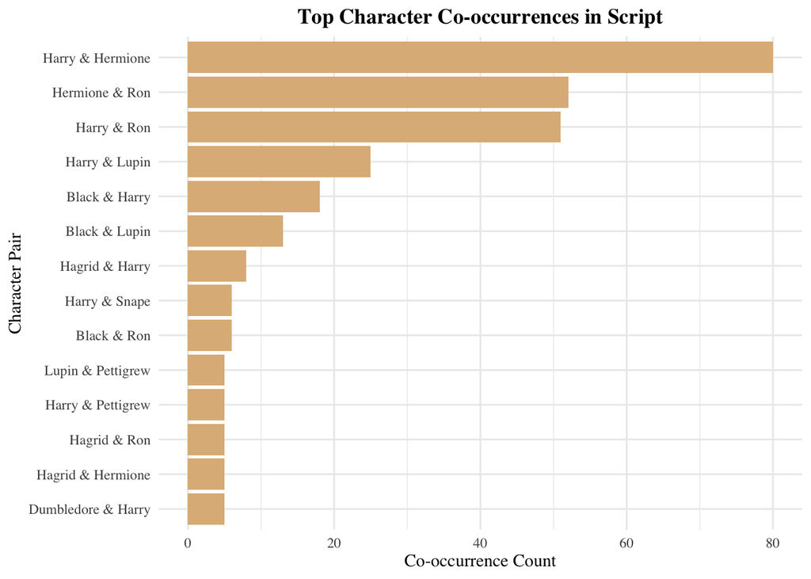

```r
# plot for script
co_occurrence_script %>%
  slice_max(n, n = 10) %>%
  mutate(pair = paste(item1, "&", item2)) %>%
  ggplot(aes(x = reorder(pair, n), y = n)) +
  geom_col(fill = "#DEB887") +
  coord_flip() +
  labs(title = "Top Character Co-occurrences in Script",
       x = "Character Pair", y = "Co-occurrence Count") +
  theme_minimal(base_family = "serif") +
  theme(plot.title = element_text(hjust = 0.5, face = "bold"))
```